# PHASE 2

# DATA MINING PHASE 2

## Main Goal :

### nowdays laptops are important because they offer portability, convenience, and functionality. since they allow us to work, study, connect with other people it become an essential tools for us to do our work and study, and the most important factor to choose a laptop is the price so our role in this project is predict prices from different companies depending on several feature such as type name, CPU, GPU, screen resolution and more. we chose this dataset because we think it will help us build a classification and clustering model that will help others choose the appropriate laptop that satisfies their prefrences and budget.

## Dataset source :

### https://www.kaggle.com/datasets/muhammetvarl/laptop-price

## Number of objects :

### 1303

## Number of attribute :

### 13

## dataset summary :

##### 13- Price_euros : Numeric - price in euro - ranges between 174 to 6099 euros.

## class lables :

##### inexpensive

##### ideal price

##### moderetly expensive

##### expinsive

##### very expensive

##### importing needed packages

```r
library(stringr)
library(tidyr)
library(data.table)

library(dplyr)
library(outliers)
library(ggplot2)
library(plotly)
```

#### dataset importing

```r
library(readr)
dataset <- read.csv("dataset.csv")
View(dataset)
```

### Raw data set

```r
# Display the first 10 rows
head(dataset, 10)
```

|  | laptop_ID | Company | Product | TypeName | Inches | ScreenResolution | Cpu | Ram | Memory | Gpu | OpSys | Weight | Price_euros |
| --- | --- | --- | --- | --- | --- | --- | --- | --- | --- | --- | --- | --- | --- |
| 1 | 1 | Apple | MacBook Pro | Ultrabook | 13.3 | IPS Panel Retina Display 2560x1600 | Intel Core i5 2.3GHz | 8GB | 128GB SSD | Intel Iris Plus Graphics 640 | macOS | 1.37kg | 1339.69 |
| 2 | 2 | Apple | Macbook Air | Ultrabook | 13.3 | 1440x900 | Intel Core i5 1.8GHz | 8GB | 128GB Flash Storage | Intel HD Graphics 6000 | macOS | 1.34kg | 898.94 |
| 3 | 3 | HP | 250 G6 | Notebook | 15.6 | Full HD 1920x1080 | Intel Core i5 7200U 2.5GHz | 8GB | 256GB SSD | Intel HD Graphics 620 | No OS | 1.86kg | 575.00 |
| 4 | 4 | Apple | MacBook Pro | Ultrabook | 15.4 | IPS Panel Retina Display 2880x1800 | Intel Core i7 2.7GHz | 16GB | 512GB SSD | AMD Radeon Pro 455 | macOS | 1.83kg | 2537.45 |
| 5 | 5 | Apple | MacBook Pro | Ultrabook | 13.3 | IPS Panel Retina Display 2560x1600 | Intel Core i5 3.1GHz | 8GB | 256GB SSD | Intel Iris Plus Graphics 650 | macOS | 1.37kg | 1803.60 |
| 6 | 6 | Acer | Aspire 3 | Notebook | 15.6 | 1366x768 | AMD A9-Series 9420 3GHz | 4GB | 500GB HDD | AMD Radeon R5 | Windows 10 | 2.1kg | 400.00 |
| 7 | 7 | Apple | MacBook Pro | Ultrabook | 15.4 | IPS Panel Retina Display 2880x1800 | Intel Core i7 2.2GHz | 16GB | 256GB Flash Storage | Intel Iris Pro Graphics | Mac OS X | 2.04kg | 2139.97 |
| 8 | 8 | Apple | Macbook Air | Ultrabook | 13.3 | 1440x900 | Intel Core i5 1.8GHz | 8GB | 256GB Flash Storage | Intel HD Graphics 6000 | macOS | 1.34kg | 1158.70 |
| 9 | 9 | Asus | ZenBook UX430UN | Ultrabook | 14.0 | Full HD 1920x1080 | Intel Core i7 8550U 1.8GHz | 16GB | 512GB SSD | Nvidia GeForce MX150 | Windows 10 | 1.3kg | 1495.00 |
| 10 | 10 | Acer | Swift 3 | Ultrabook | 14.0 | IPS Panel Full HD 1920x1080 | Intel Core i5 8250U 1.6GHz | 8GB | 256GB SSD | Intel UHD Graphics 620 | Windows 10 | 1.6kg | 770.00 |

```r
# Display the last 10 rows
tail(dataset, 10)
```

|  | laptop_ID | Company | Product | TypeName | Inches | ScreenResolution | Cpu | Ram | Memory | Gpu | OpSys | Weight | Price_euros |
| --- | --- | --- | --- | --- | --- | --- | --- | --- | --- | --- | --- | --- | --- |
| 1294 | 1311 | Lenovo | IdeaPad Y700-15ISK | Notebook | 15.6 | IPS Panel Full HD 1920x1080 | Intel Core i7 6700HQ 2.6GHz | 8GB | 1TB HDD | Nvidia GeForce GTX 960M | Windows 10 | 2.6kg | 899.00 |
| 1295 | 1312 | HP | Pavilion 15-AW003nv | Notebook | 15.6 | Full HD 1920x1080 | AMD A9-Series 9410 2.9GHz | 6GB | 1.0TB Hybrid | AMD Radeon R7 M440 | Windows 10 | 2.04kg | 549.99 |
| 1296 | 1313 | Dell | Inspiron 3567 | Notebook | 15.6 | 1366x768 | Intel Core i7 7500U 2.7GHz | 8GB | 1TB HDD | AMD Radeon R5 M430 | Linux | 2.3kg | 805.99 |
| 1297 | 1314 | HP | Stream 11-Y000na | Netbook | 11.6 | 1366x768 | Intel Celeron Dual Core N3060 1.6GHz | 2GB | 32GB Flash Storage | Intel HD Graphics 400 | Windows 10 | 1.17kg | 209.00 |
| 1298 | 1315 | Asus | X556UJ-XO044T (i7-6500U/4GB/500GB/GeForce | Notebook | 15.6 | 1366x768 | Intel Core i7 6500U 2.5GHz | 4GB | 500GB HDD | Nvidia GeForce 920M | Windows 10 | 2.2kg | 720.32 |
| 1299 | 1316 | Lenovo | Yoga 500-14ISK | 2 in 1 Convertible | 14.0 | IPS Panel Full HD / Touchscreen 1920x1080 | Intel Core i7 6500U 2.5GHz | 4GB | 128GB SSD | Intel HD Graphics 520 | Windows 10 | 1.8kg | 638.00 |
| 1300 | 1317 | Lenovo | Yoga 900-13ISK | 2 in 1 Convertible | 13.3 | IPS Panel Quad HD+ / Touchscreen 3200x1800 | Intel Core i7 6500U 2.5GHz | 16GB | 512GB SSD | Intel HD Graphics 520 | Windows 10 | 1.3kg | 1499.00 |
| 1301 | 1318 | Lenovo | IdeaPad 100S-14IBR | Notebook | 14.0 | 1366x768 | Intel Celeron Dual Core N3050 1.6GHz | 2GB | 64GB Flash Storage | Intel HD Graphics | Windows 10 | 1.5kg | 229.00 |
| 1302 | 1319 | HP | 15-AC110nv (i7-6500U/6GB/1TB/Radeon | Notebook | 15.6 | 1366x768 | Intel Core i7 6500U 2.5GHz | 6GB | 1TB HDD | AMD Radeon R5 M330 | Windows 10 | 2.19kg | 764.00 |
| 1303 | 1320 | Asus | X553SA-XX031T (N3050/4GB/500GB/W10) | Notebook | 15.6 | 1366x768 | Intel Celeron Dual Core N3050 1.6GHz | 4GB | 500GB HDD | Intel HD Graphics | Windows 10 | 2.2kg | 369.00 |

### 1: Missing values and duplicated rows

##### There are no missing values in our dataset and Nor duplicated rows

```r
#check for missing values
sum(is.na(dataset))
```

```
[1] 0
```

```r
cat("Number of duplicate rows: ")
```

```
Number of duplicate rows:
```

```r
sum(duplicated(dataset))
```

```
[1] 0
```

### 2: converting to numeric

##### We convert Weight attribute from char to numeric by removing the “kg” suffix to apply any needed mathematical operations.

```r
#Find unique values in Weight
unique(dataset$Weight)
```

```
  [1] "1.37kg"  "1.34kg"  "1.86kg"  "1.83kg"  "2.1kg"   "2.04kg"  "1.3kg"   "1.6kg"   "2.2kg"   "0.92kg"
 [11] "1.22kg"  "0.98kg"  "2.5kg"   "1.62kg"  "1.91kg"  "2.3kg"   "1.35kg"  "1.88kg"  "1.89kg"  "1.65kg"
 [21] "2.71kg"  "1.2kg"   "1.44kg"  "2.8kg"   "2kg"     "2.65kg"  "2.77kg"  "3.2kg"   "0.69kg"  "1.49kg"
 [31] "2.4kg"   "2.13kg"  "2.43kg"  "1.7kg"   "1.4kg"   "1.8kg"   "1.9kg"   "3kg"     "1.252kg" "2.7kg"
 [41] "2.02kg"  "1.63kg"  "1.96kg"  "1.21kg"  "2.45kg"  "1.25kg"  "1.5kg"   "2.62kg"  "1.38kg"  "1.58kg"
 [51] "1.85kg"  "1.23kg"  "1.26kg"  "2.16kg"  "2.36kg"  "2.05kg"  "1.32kg"  "1.75kg"  "0.97kg"  "2.9kg"
 [61] "2.56kg"  "1.48kg"  "1.74kg"  "1.1kg"   "1.56kg"  "2.03kg"  "1.05kg"  "4.4kg"   "1.90kg"  "1.29kg"
 [71] "2.0kg"   "1.95kg"  "2.06kg"  "1.12kg"  "1.42kg"  "3.49kg"  "3.35kg"  "2.23kg"  "4.42kg"  "2.69kg"
 [81] "2.37kg"  "4.7kg"   "3.6kg"   "2.08kg"  "4.3kg"   "1.68kg"  "1.41kg"  "4.14kg"  "2.18kg"  "2.24kg"
 [91] "2.67kg"  "2.14kg"  "1.36kg"  "2.25kg"  "2.15kg"  "2.19kg"  "2.54kg"  "3.42kg"  "1.28kg"  "2.33kg"
[101] "1.45kg"  "2.79kg"  "1.84kg"  "2.6kg"   "2.26kg"  "3.25kg"  "1.59kg"  "1.13kg"  "1.78kg"  "1.10kg"
[111] "1.15kg"  "1.27kg"  "1.43kg"  "2.31kg"  "1.16kg"  "1.64kg"  "2.17kg"  "1.47kg"  "3.78kg"  "1.79kg"
[121] "0.91kg"  "1.99kg"  "4.33kg"  "1.93kg"  "1.87kg"  "2.63kg"  "3.4kg"   "3.14kg"  "1.94kg"  "1.24kg"
[131] "4.6kg"   "4.5kg"   "2.73kg"  "1.39kg"  "2.29kg"  "2.59kg"  "2.94kg"  "1.14kg"  "3.8kg"   "3.31kg"
[141] "1.09kg"  "3.21kg"  "1.19kg"  "1.98kg"  "1.17kg"  "4.36kg"  "1.71kg"  "2.32kg"  "4.2kg"   "1.55kg"
[151] "0.81kg"  "1.18kg"  "2.72kg"  "1.31kg"  "0.920kg" "3.74kg"  "1.76kg"  "1.54kg"  "2.83kg"  "2.07kg"
[161] "2.38kg"  "3.58kg"  "1.08kg"  "2.20kg"  "2.75kg"  "1.70kg"  "2.99kg"  "1.11kg"  "2.09kg"  "4kg"
[171] "3.0kg"   "0.99kg"  "3.52kg"  "2.591kg" "2.21kg"  "3.3kg"   "2.191kg" "2.34kg"  "4.0kg"
```

```r
#sub the kg from Weight attribute
dataset$Weight <- gsub("kg", "", dataset$Weight)
#convert Weight to numeric
dataset$Weight<- as.numeric(as.character(dataset$Weight))

#Find unique values in Ram
unique(dataset$Ram)
```

```
[1] "8GB"  "16GB" "4GB"  "2GB"  "12GB" "6GB"  "32GB" "24GB" "64GB"
```

```r
#Encode the Ram attribute
dataset$Ram=factor(dataset$Ram,levels=c("8GB","16GB","4GB","2GB","12GB","6GB","32GB","24GB","64GB"),labels=c("8","16","4","2","12","6","32","24","64"))
dataset$Ram<- as.numeric(as.character(dataset$Ram))

#dataset$OpSys<- as.numeric(as.character(dataset$OpSys))
```

##### correcting the type mismatch of Screen resolution to numeric

##### find the Screen resolution product (first and second factors cut from the other nominal explenation)

```r
dataset$ScreenResolutionupdate <- gsub(".* ", "", dataset$ScreenResolution)


#find the Screen resulotion product (first factor)
dataset$ScreenResolutionFactor1 <- gsub(".*x", "", dataset$ScreenResolutionupdate)

#find the Screen resolution product (second factor)
dataset$ScreenResolutionfactor2 <- gsub("x.*", "", dataset$ScreenResolutionupdate)

#enforce numeric type to both attribtes to apply mathematical operations
dataset$ScreenResolutionFactor1<- as.numeric(as.character(dataset$ScreenResolutionFactor1))
dataset$ScreenResolutionfactor2<- as.numeric(as.character(dataset$ScreenResolutionfactor2))

#apply the mathematical operation to the ScreenResolution attribute
dataset$ScreenResolution <- dataset$ScreenResolutionFactor1*dataset$ScreenResolutionfactor2

#delete added attribute as the trigger redunduncy
dataset$ScreenResolutionFactor1<-NULL
dataset$ScreenResolutionfactor2 <-NULL
dataset$ScreenResolutionupdate<-NULL
```

### 3: Detecting outliers

##### We got 29 row as box plot outliers for Price_euros. All detected outliers were above the maximume value for price. After analyzing them we saw that the highest price was the laptop with id 200, which was 6099 €, we checked its specifications, and noticed that it was gaming device with touchscreen, 4k screen resolution, i7 CPU, 32 GB Ram, and 1TB SSD memory. After analyzing all the rows, we concluded that each laptop price and its specifications were reasonable, and there is no reason to delete them as outliers.

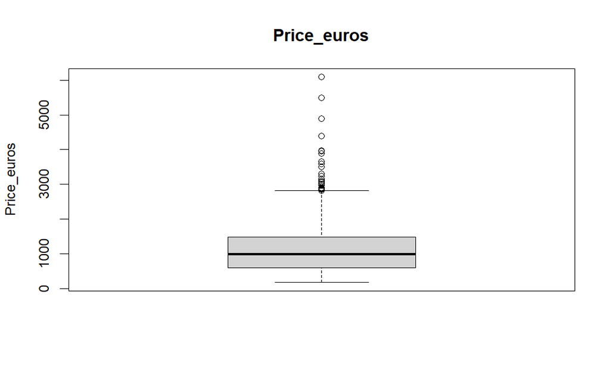

```r
#Price_euros
bp_price <- boxplot(dataset$Price_euros,
        ylab = "Price_euros",
        main = "Price_euros" )
```

```r
outliers <- bp_price$out
price_Outliers <- dataset[dataset$Price_euros %in% outliers, c(1:12)]

# Display the first 10 rows
head(price_Outliers, 5)
```

|  | laptop_ID | Company | Product | TypeName | Inches | ScreenResolution | Cpu | Ram | Memory | Gpu | OpSys | Weight |
| --- | --- | --- | --- | --- | --- | --- | --- | --- | --- | --- | --- | --- |
| 18 | 18 | Apple | MacBook Pro | Ultrabook | 15.4 | 5184000 | Intel Core i7 2.9GHz | 16 | 512GB SSD | AMD Radeon Pro 560 | macOS | 1.83 |
| 191 | 194 | Lenovo | Thinkpad Yoga | 2 in 1 Convertible | 14.0 | 3686400 | Intel Core i7 7500U 2.7GHz | 16 | 1TB SSD | Intel HD Graphics 620 | Windows 10 | 1.42 |
| 197 | 200 | Razer | Blade Pro | Gaming | 17.3 | 8294400 | Intel Core i7 7820HK 2.9GHz | 32 | 1TB SSD | Nvidia GeForce GTX 1080 | Windows 10 | 3.49 |
| 205 | 208 | Dell | Precision 7520 | Workstation | 15.6 | 8294400 | Intel Xeon E3-1505M V6 3GHz | 16 | 256GB SSD + 1TB HDD | Nvidia Quadro M1200 | Windows 10 | 2.80 |
| 239 | 243 | Asus | ROG G703VI-E5062T | Gaming | 17.3 | 2073600 | Intel Core i7 7820HK 2.9GHz | 32 | 512GB SSD + 1TB HDD | Nvidia GeForce GTX 1080 | Windows 10 | 4.70 |

```r
#Maximume outlier Price_euros
cat("The Maximum Outlier in Price_euros: ")
```

```
The Maximum Outlier in Price_euros:
```

```r
max(price_Outliers$Price_euros)
```

```
[1] -Inf
```

```r
cat("Maximum value for price: ")
```

```
Maximum value for price:
```

```r
bp_price$stats[5]
```

```
[1] 2813.75
```

##### We analyzed the 46 Weight outliers. All detected outliers were above the maximume value. We noticed that most laptops are of type gaming and of 17 inches. The maximume weight is 4.7 kg, and after checking all the rows and analyzing the scatter plot between inches and weight, we concluded that there is no reason to delete them as outliers since high weight for gaming laptops with large screens (inches) is normal.

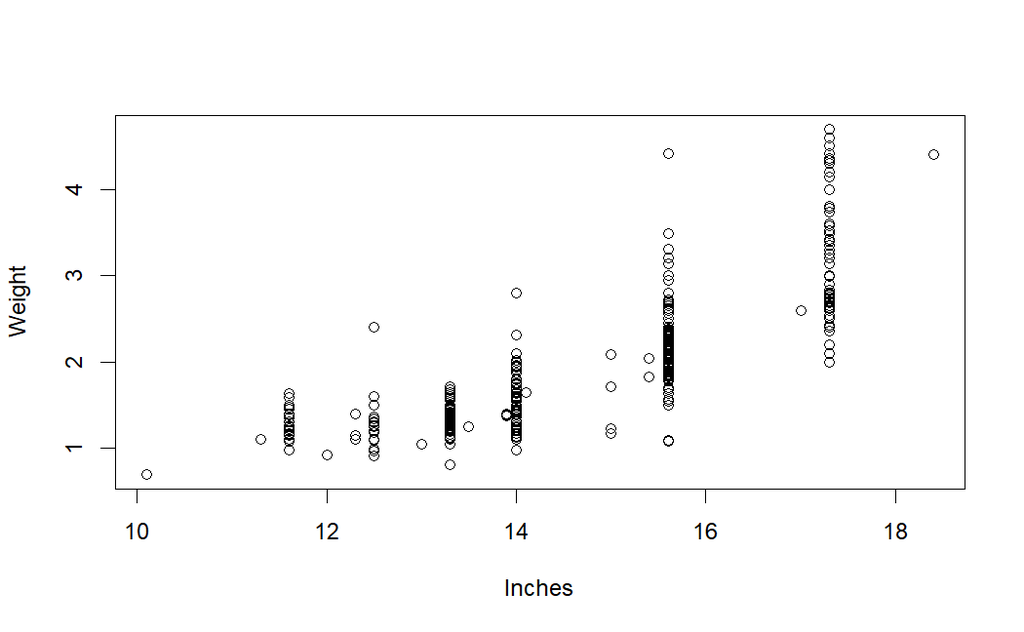

```r
plot(dataset$Inches, dataset$Weight, xlab="Inches", ylab="Weight")
```

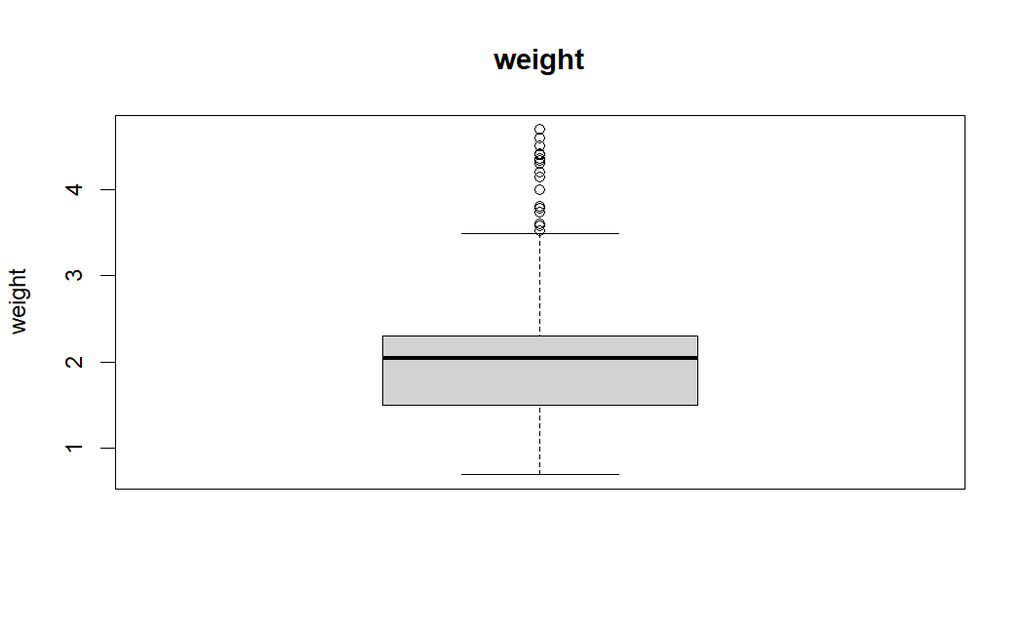

```r
#Weight
bp_weight <- boxplot(dataset$Weight,
        ylab = "weight",
        main = "weight" )
```

```r
outliers <- bp_weight$out
weight_Outliers <- dataset[dataset$Weight %in% outliers, c(1:12)]

# Display the first 10 rows
head(weight_Outliers, 5)
```

|  | laptop_ID | Company | Product | TypeName | Inches | ScreenResolution | Cpu | Ram | Memory | Gpu | OpSys | Weight |
| --- | --- | --- | --- | --- | --- | --- | --- | --- | --- | --- | --- | --- |
| 178 | 181 | MSI | GT80S 6QF-074US | Gaming | 18.4 | 2073600 | Intel Core i7 6920HQ 2.9GHz | 32 | 512GB SSD + 1TB HDD | Nvidia GTX 980 SLI | Windows 10 | 4.40 |
| 225 | 229 | Dell | Alienware 17 | Gaming | 17.3 | 2073600 | Intel Core i7 7700HQ 2.8GHz | 16 | 256GB SSD + 1TB HDD | Nvidia GeForce GTX 1060 | Windows 10 | 4.42 |
| 239 | 243 | Asus | ROG G703VI-E5062T | Gaming | 17.3 | 2073600 | Intel Core i7 7820HK 2.9GHz | 32 | 512GB SSD + 1TB HDD | Nvidia GeForce GTX 1080 | Windows 10 | 4.70 |
| 248 | 252 | Asus | Rog G701VIK-BA060T | Gaming | 17.3 | 2073600 | Intel Core i7 7820HK 2.9GHz | 16 | 256GB SSD | Nvidia GeForce GTX 1080 | Windows 10 | 3.60 |
| 252 | 256 | Asus | ROG G752VSK-GC493T | Gaming | 17.3 | 2073600 | Intel Core i7 7700HQ 2.8GHz | 16 | 256GB SSD + 1TB HDD | Nvidia GeForce GTX 980M | Windows 10 | 4.30 |

```r
#Maximum outlier weight
cat("The Maximum Outlier in weight: ")
```

```
The Maximum Outlier in weight:
```

```r
max(weight_Outliers$Weight)
```

```
[1] 4.7
```

```r
cat("Maximum value for weight: ")
```

```
Maximum value for weight:
```

```r
bp_weight$stats[5]
```

```
[1] 3.49
```

##### The outliers detected from the boxplot was 1 above the maximume value, and 38 outlier under the minumum value. The laptop above the maximum value was 18.4 inches gaming laptop and 4.4 kg. For the minumum values, they were all from type (2 in 1 Convertible),(Ultrabook), and (Netbook) which they are popular for their light weight and small sizes. From the the previous scatter plot with the positive correlation between inches and weight, We decided that the detected outlier will not be removed since they are not really outliers.

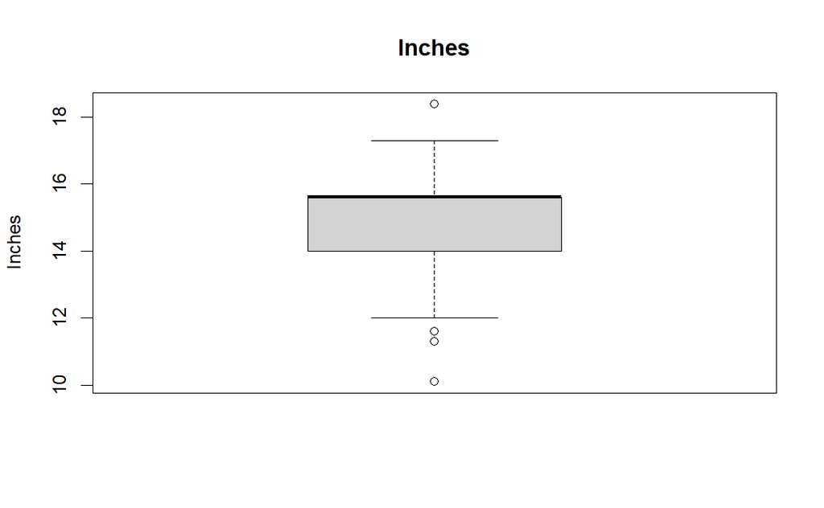

```r
#Inches
bp_Inches <- boxplot(dataset$Inches,
        ylab = "Inches",
        main = "Inches" )
```

```r
outliers <- bp_Inches$out
Inches_Outliers <- dataset[dataset$Inches %in% outliers, c(1:12)]

# Display the first 10 rows
head(Inches_Outliers, 5)
```

|  | laptop_ID | Company | Product | TypeName | Inches | ScreenResolution | Cpu | Ram | Memory | Gpu | OpSys | Weight |
| --- | --- | --- | --- | --- | --- | --- | --- | --- | --- | --- | --- | --- |
| 21 | 21 | Asus | Vivobook E200HA | Netbook | 11.6 | 1049088 | Intel Atom x5-Z8350 1.44GHz | 2 | 32GB Flash Storage | Intel HD Graphics 400 | Windows 10 | 0.98 |
| 51 | 51 | Lenovo | Yoga Book | 2 in 1 Convertible | 10.1 | 2304000 | Intel Atom x5-Z8550 1.44GHz | 4 | 64GB Flash Storage | Intel HD Graphics 400 | Android | 0.69 |
| 178 | 181 | MSI | GT80S 6QF-074US | Gaming | 18.4 | 2073600 | Intel Core i7 6920HQ 2.9GHz | 32 | 512GB SSD + 1TB HDD | Nvidia GTX 980 SLI | Windows 10 | 4.40 |
| 315 | 319 | Asus | VivoBook Flip | 2 in 1 Convertible | 11.6 | 1049088 | Intel Celeron Dual Core N3350 1.1GHz | 2 | 32GB Flash Storage | Intel HD Graphics 500 | Windows 10 | 1.10 |
| 320 | 324 | Acer | TravelMate B | Notebook | 11.6 | 1049088 | Intel Pentium Quad Core N3710 1.6GHz | 4 | 128GB Flash Storage | Intel HD Graphics 405 | Windows 10 | 1.40 |

```r
#Maximum outlier Inches
cat("The Maximum Outlier in Inches: ")
```

```
The Maximum Outlier in Inches:
```

```r
max(Inches_Outliers$Inches)
```

```
[1] 18.4
```

```r
cat("Maximum value for Inches: ")
```

```
Maximum value for Inches:
```

```r
bp_Inches$stats[5]
```

```
[1] 17.3
```

```r
cat("Minumum value for Inches: ")
```

```
Minumum value for Inches:
```

```r
bp_Inches$stats[1]
```

```
[1] 12
```

### 4: Data simplification and adding attributes

### Data simplification

#### Data simplification on CPU and GPU

##### CPU and GPU attributes are nominal, CPU has 118 unique value, and GPU has 110 unique value. We could not use them until we categorized CPU into 10 categories, and GPU into 7. We used the the brand and generation to categorize them. This step enabled us to generate usefull graphs out of these attributes.

```r
cat("unique values in CPU: ")
```

```
unique values in CPU:
```

```r
length(unique(dataset$Cpu))
```

```
[1] 118
```

```r
cat("unique values in GPU: ")
```

```
unique values in GPU:
```

```r
length(unique(dataset$Gpu))
```

```
[1] 110
```

```r
# simplifying CPU types
pattern_categories <- data.frame(
              Cpu = c("Intel Core i3 .*","Intel Core i5 .*", "Intel Core i7 .*", "Intel Core i9 .*",
                          "Intel Core M.*", "(?i)Intel Atom x.*",
                          "Intel Celeron .*","Intel Pentium .*",
                          "AMD A.*", "AMD E.*"),
                Category = c("Intel Core i3", "Intel Core i5", "Intel Core i7","Intel Core i9",
                             "Intel Core M", "Intel Atom x",
                             "Intel Celeron", "Intel Pentium",
                             "AMD A-Series", "AMD E-Series")
  )
# assigning categories based on patterns
assign_category <- function(Cpu) {
  for (i in 1:nrow(pattern_categories)) {
    if (grepl(pattern_categories$Cpu[i], Cpu)) {
      return(pattern_categories$Category[i])
    }
  }
  return("Other")  # if no patterns match, it assigns it to "Other"
}

# Create a new column with CPU categories
dataset$CPU <- sapply(dataset$Cpu, assign_category)
dataset$Cpu<-NULL
```

```r
# simplifying GPU types
gpu_pattern_categories <- data.frame(
  Gpu = c("Intel Iris.*", "Intel HD Graphics.*", "AMD Radeon.*", "Nvidia GeForce.*", "Intel UHD Graphics.*", "Nvidia Quadro .*"),
  Category = c("Intel Iris Graphics", "Intel HD Graphics", "AMD Radeon Graphics", "Nvidia GeForce Graphics", "Intel UHD Graphics", "Nvidia Quadro")
)

# Function to assign GPU categories based on patterns
assign_gpu_category <- function(gpu_name) {
  for (i in 1:nrow(gpu_pattern_categories)) {
    if (grepl(gpu_pattern_categories$Gpu[i], gpu_name)) {
      return(gpu_pattern_categories$Category[i])
    }
  }
  return("Other")  # Assign to "Other" category if no patterns match
}


# Create a new column "Gpu_Category"
dataset$GPU <- sapply(dataset$Gpu, assign_gpu_category)
dataset$Gpu<-NULL
```

#### Jitter plot for CPU and GPU

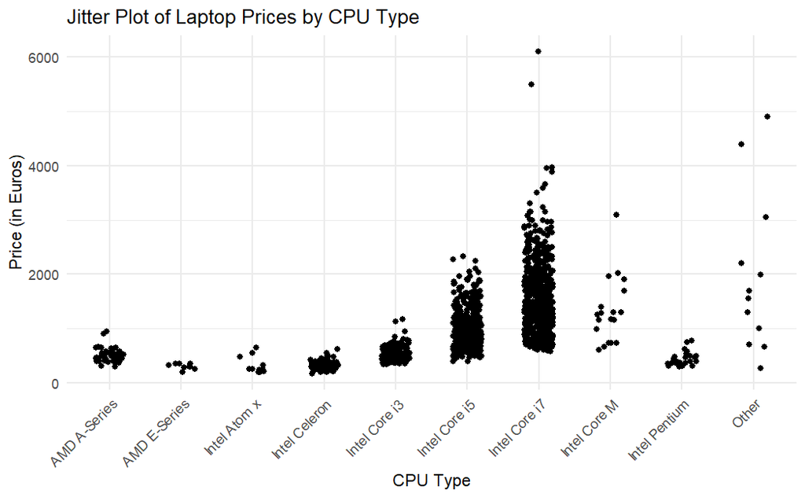

```r
# Plot CPU
ggplot(dataset, aes(x = CPU, y = Price_euros)) +
  geom_jitter(width = 0.2, height = 0) +
  labs(title = "Jitter Plot of Laptop Prices by CPU Type", x = "CPU Type", y = "Price (in Euros)") +
  theme_minimal() +
  theme(axis.text.x = element_text(angle = 45, hjust = 1))
```

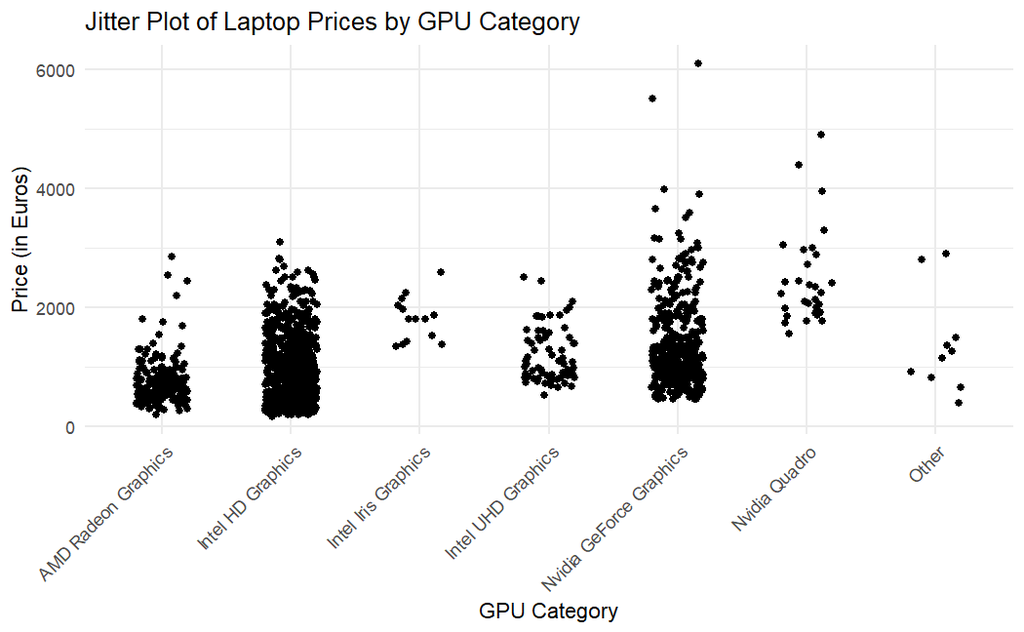

```r
#plot GPU
ggplot(dataset, aes(x = GPU, y = Price_euros)) +
  geom_jitter(width = 0.2, height = 0) +
  labs(title = "Jitter Plot of Laptop Prices by GPU Category", x = "GPU Category", y = "Price (in Euros)") +
  theme_minimal() +
  theme(axis.text.x = element_text(angle = 45,hjust=1))
```

#### Data simplification on Memory

##### Since Memory attribute had more than one information, we split the Memory attribute into: Memory type, and memory size -where sizes unit is in GB- to show the effect of each information.

##### We can notice that “Flash Storage”, “HDD”, and “Hybrid” is in the cheaper range. “SSD has a large price range so it can be categorized as”Low”, “Average” or “High”.For “SSD&HDD” we see that its price range is large, it can be categorized as “Average” or “High”.

##### Memory sizes that are (16,32,64)GB can be categorized as “Low”. For (500,1000)GB it can be described as “Low” or “Average”. For (256,1024,1128)GB it can be categorized as “Average” or “High”. For (512,1256)GB it can be categorized as “High”.

```r
# categorizing Memory types
dataset$Memory=factor(dataset$Memory,levels=c("128GB SSD" ,  "128GB Flash Storage" ,
                                              "256GB SSD" ,                    "512GB SSD",
                                              "500GB HDD",                     "256GB Flash Storage" ,
                                              "1TB HDD",                       "32GB Flash Storage"  ,
                                              "128GB SSD +  1TB HDD",          "256GB SSD +  256GB SSD",
                                              "64GB Flash Storage",            "256GB SSD +  1TB HDD",
                                              "256GB SSD +  2TB HDD" ,         "32GB SSD",
                                              "2TB HDD",                       "64GB SSD",
                                              "1.0TB Hybrid",                  "512GB SSD +  1TB HDD",
                                              "1TB SSD" ,                      "256GB SSD +  500GB HDD",
                                              "128GB SSD +  2TB HDD",          "512GB SSD +  512GB SSD",
                                              "16GB SSD",                      "16GB Flash Storage",
                                              "512GB SSD +  256GB SSD" ,       "512GB SSD +  2TB HDD",
                                              "64GB Flash Storage +  1TB HDD", "180GB SSD",
                                              "1TB HDD +  1TB HDD" ,           "32GB HDD",
                                              "1TB SSD +  1TB HDD" ,           "512GB Flash Storage",
                                              "128GB HDD",                     "240GB SSD",
                                              "8GB SSD",                       "508GB Hybrid",
                                              "1.0TB HDD",                     "512GB SSD +  1.0TB Hybrid",
                                              "256GB SSD +  1.0TB Hybrid"),
                      labels=c("128GB SSD" ,  "128GB Flash Storage" ,
                               "256GB SSD" ,                    "512GB SSD",
                               "500GB HDD",                     "256GB Flash Storage" ,
                               "1000GB HDD",                       "32GB Flash Storage"  ,
                               "1128GB SSD&HDD",          "512GB SSD  SSD",           "64GB Flash Storage",            "1256GB SSD&HDD",
                               "2256GB SSD HDD" ,         "32GB SSD",
                               "2000GB HDD",                       "64GB SSD",
                               "1000GB Hybrid",                  "1512GB SSD&HDD",
                               "1000GB SSD" ,                      "756GB SSD&HDD",
                               "2128GB SSD&HDD",          "1024GB SSD",
                               "16GB SSD",                      "16GB Flash Storage",
                               "768GB SSD" ,       "2512GB SSD&HDD",
                               "164GB Flash Storage HDD", "180GB SSD",
                               "2000GB HDD" ,           "32GB HDD",
                               "2000GB SSD&HDD" ,           "512GB Flash Storage",
                               "128GB HDD",                     "240GB SSD",
                               "8GB SSD",                       "508GB Hybrid",
                               "1000GB HDD",                     "1512GB SSD&Hybrid",
                               "1256GB SSD&Hybrid"))

#find the memory type and set it as an attribute
dataset$MemoryType <- gsub(".*GB", "", dataset$Memory)

#find the memory size and set it as an attribute
dataset$MemorySize <- gsub("GB.*", "", dataset$Memory)

#convert memory size to numeric
dataset$MemorySize<- as.numeric(as.character(dataset$MemorySize))

# remove Memory attribute to reduce redundency
dataset$Memory<-NULL
```

### 5: statistical simmaries

##### This function provides insights into the central tendency of the data through measures like mean and median. offering a sense of the data’s central location.you can notice the mean of the Price_euros is 1124,for the Inches it is 15.02,for the Weight its 2.039 ,the median for the Price_euros is 977.0 ,the median for the weight is 2.040 ,the median for the Inches is 15.6 The summary includes information about the spread of the data, providing the minimum and maximum values. This gives a sense of the range within which the data is distributed,for the Price_euros the range is between 174 and 6099 ,for the Weight it is between 0.690 and 4.700,for the Inches it is between 10.1 and 18.4. d

```r
summary(dataset)
```

```
   laptop_ID        Company            Product            TypeName             Inches      ScreenResolution
 Min.   :   1.0   Length:1303        Length:1303        Length:1303        Min.   :10.10   Min.   :1049088
 1st Qu.: 331.5   Class :character   Class :character   Class :character   1st Qu.:14.00   1st Qu.:1440000
 Median : 659.0   Mode  :character   Mode  :character   Mode  :character   Median :15.60   Median :2073600
 Mean   : 660.2                                                            Mean   :15.02   Mean   :2168807
 3rd Qu.: 990.5                                                            3rd Qu.:15.60   3rd Qu.:2073600
 Max.   :1320.0                                                            Max.   :18.40   Max.   :8294400
      Ram            OpSys               Weight       Price_euros       CPU                GPU
 Min.   : 2.000   Length:1303        Min.   :0.690   Min.   : 174   Length:1303        Length:1303
 1st Qu.: 4.000   Class :character   1st Qu.:1.500   1st Qu.: 599   Class :character   Class :character
 Median : 8.000   Mode  :character   Median :2.040   Median : 977   Mode  :character   Mode  :character
 Mean   : 8.382                      Mean   :2.039   Mean   :1124
 3rd Qu.: 8.000                      3rd Qu.:2.300   3rd Qu.:1488
 Max.   :64.000                      Max.   :4.700   Max.   :6099
  MemoryType          MemorySize
 Length:1303        Min.   :   8.0
 Class :character   1st Qu.: 256.0
 Mode  :character   Median : 500.0
                    Mean   : 610.2
                    3rd Qu.:1000.0
                    Max.   :2512.0
```

##### The mean is a central tendency metric that is frequently used to describe the average value of a data set.we can see that mean of Price_euros column is the highest(1123.687) whereras mean of Weight column (2.038734) is the lowest.

```r
#Mean
mean(dataset$Price_euros)
```

```
[1] 1123.687
```

```r
mean(dataset$Inches)
```

```
[1] 15.01719
```

```r
mean(dataset$Weight)
```

```
[1] 2.038734
```

##### The median is a measure of central tendency that represents the data set’s middle value. It is not as influenced by extreme values like the mean.we can see that center of the of the Price_euros column is(977) which is the largest median ,and the center for the Weight column is(2.04) which is the smallest median.

```r
# Find median of all data
median(dataset$Price_euros)
```

```
[1] 977
```

```r
median(dataset$Company)
```

```
[1] "HP"
```

```r
median(dataset$Product)
```

```
[1] "Legion Y520-15IKBN"
```

```r
median(dataset$TypeName)
```

```
[1] "Notebook"
```

```r
median(dataset$Inches)
```

```
[1] 15.6
```

```r
median(dataset$ScreenResolution)
```

```
[1] 2073600
```

```r
median(dataset$CPU)
```

```
[1] "Intel Core i5"
```

```r
median(dataset$Weight)
```

```
[1] 2.04
```

```r
median(dataset$OpSys)
```

```
[1] "Windows 10"
```

```r
median(dataset$Ram)
```

```
[1] 8
```

```r
median(dataset$GPU)
```

```
[1] "Intel HD Graphics"
```

```r
median(dataset$MemorySize)
```

```
[1] 500
```

```r
median(dataset$MemoryType)
```

```
[1] " SSD"
```

##### The mode is the most often occurring value in for a certain column. It indicates the most common occurrence for a certain attribute.All of the columns in our data collection have the one mode, indicating that it is unimodal.

```r
data_table <- table(dataset$Price_euros)
mode_result <- names(data_table[which.max(data_table)])
print(mode_result)
```

```
[1] "1099"
```

```r
data_table <- table(dataset$CPU)
mode_result <- names(data_table[which.max(data_table)])
print(mode_result)
```

```
[1] "Intel Core i7"
```

```r
data_table <- table(dataset$Company)
mode_result <- names(data_table[which.max(data_table)])
print(mode_result)
```

```
[1] "Dell"
```

```r
data_table <- table(dataset$Product)
mode_result <- names(data_table[which.max(data_table)])
print(mode_result)
```

```
[1] "XPS 13"
```

```r
data_table <- table(dataset$TypeName)
mode_result <- names(data_table[which.max(data_table)])
print(mode_result)
```

```
[1] "Notebook"
```

```r
data_table <- table(dataset$Inches)
mode_result <- names(data_table[which.max(data_table)])
print(mode_result)
```

```
[1] "15.6"
```

```r
data_table <- table(dataset$ScreenResolution)
mode_result <- names(data_table[which.max(data_table)])
print(mode_result)
```

```
[1] "2073600"
```

```r
data_table <- table(dataset$CPU)
mode_result <- names(data_table[which.max(data_table)])
print(mode_result)
```

```
[1] "Intel Core i7"
```

```r
data_table <- table(dataset$GPU)
mode_result <- names(data_table[which.max(data_table)])
print(mode_result)
```

```
[1] "Intel HD Graphics"
```

```r
data_table <- table(dataset$Weight)
mode_result <- names(data_table[which.max(data_table)])
print(mode_result)
```

```
[1] "2.2"
```

```r
data_table <- table(dataset$MemorySize)
mode_result <- names(data_table[which.max(data_table)])
print(mode_result)
```

```
[1] "256"
```

```r
data_table <- table(dataset$MemoryType)
mode_result <- names(data_table[which.max(data_table)])
print(mode_result)
```

```
[1] " SSD"
```

##### the range refers to the difference between the maximum and minimum values in a data set.we can see that the highest range is for the Price_euros column(174 to 6099),the lowest range is for the Weight column (0.69 to 4.70).

### Range of data.

```r
range(dataset$Price_euros)
```

```
[1]  174 6099
```

```r
range(dataset$Weight)
```

```
[1] 0.69 4.70
```

```r
range(dataset$Inches)
```

```
[1] 10.1 18.4
```

##### Calculating the variance for numeric data

##### we can see that the highest variance is for the Price_euros column (488613.6),a high variance suggests that individual data points are far from the mean, and this can indicate that the data is highly spread out.the lowest variance is the Weight column(0.4428564) a low variance indicates that the data points are close to the mean and that the data is not spread out.

```r
var(dataset$Price_euros)
```

```
[1] 488613.6
```

```r
var(dataset$Weight)
```

```
[1] 0.4428564
```

```r
var(dataset$Inches)
```

```
[1] 2.034343
```

##### relationship between price of laptop and company,we have observed that businesses like Lenovo, HP, Dell, Asus, Acer,Vero ,toshiba ,chuwi,Mediacom offer low prices .

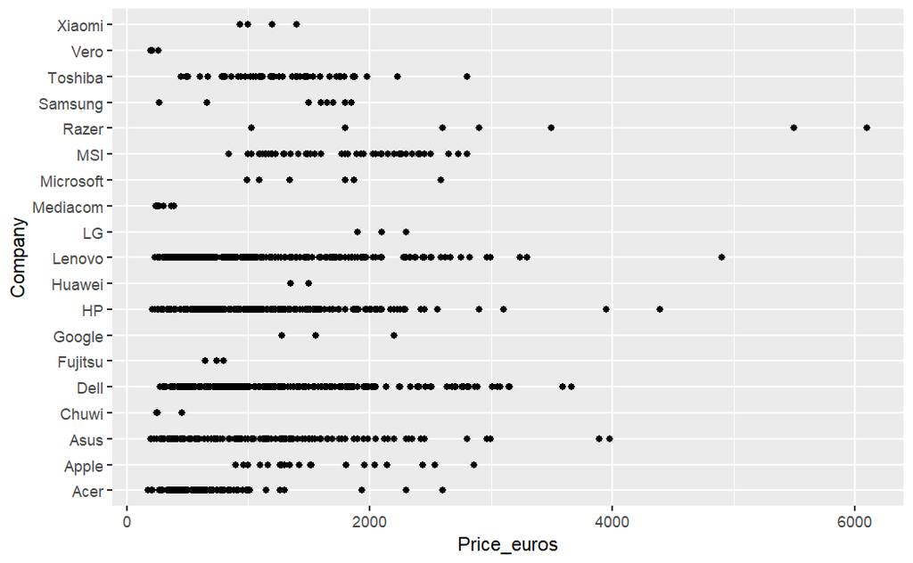

```r
ggplot(dataset,aes(Price_euros,Company))+geom_point()
```

##### From the bellow graph, the Netbook type is the most affordable type. Notebook, and 2-1 Convertible laptops are more affordable options than Gaming, and Ultrabook types. The most expensive type in our dataset is workstation type.

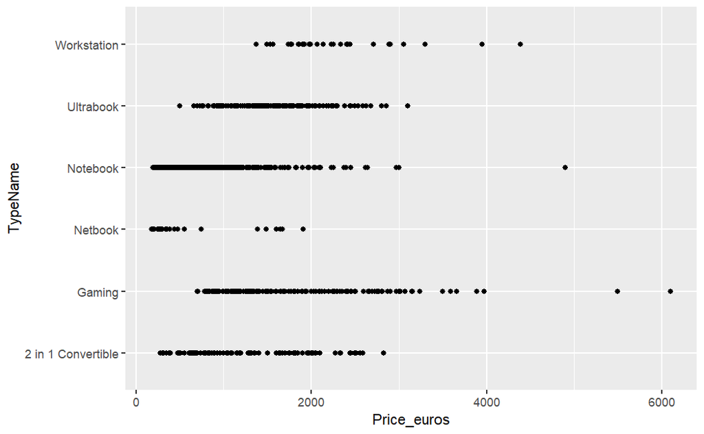

```r
ggplot(dataset,aes(Price_euros,TypeName))+geom_point()
```

##### relationship between price of laptop and Ram,I’ve discovered that RAM less than 20 GB is less expensive,and We can see from the graph that the most frequent Ram sizes are 8GB and 4GB. We can also notice that the larger the RAM size is, the higher its price.

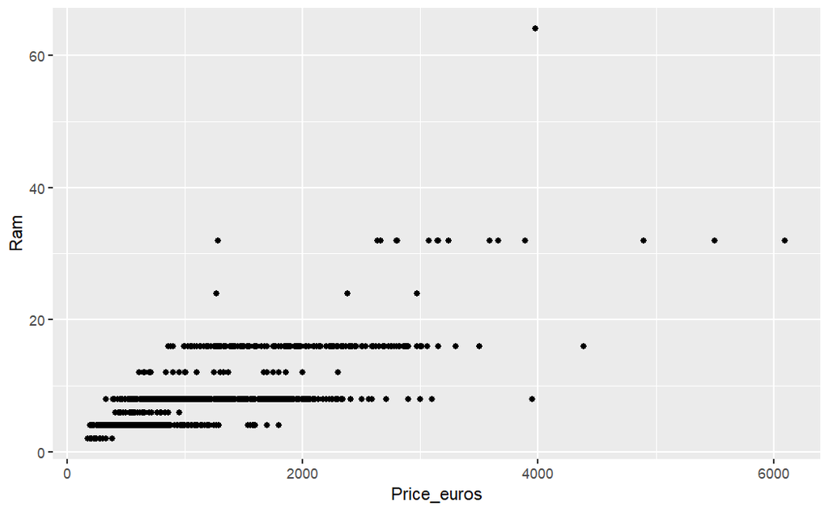

```r
ggplot(dataset,aes(Price_euros,Ram))+geom_point()
```

### 6: Graphs

#### Company Bar chart and Histogram

##### Top 5 frequent companies in out dataset are Dell, Lenovo, HP, Asus, Acer. For Dell, Lenovo, HP, and Asus, we can notice from the bar chart that thier price is moderately expensive. For Acer, it is ideal price.

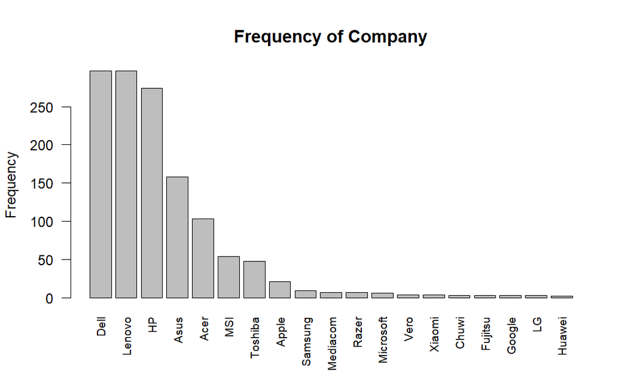

```r
#Company histogram
companyHist <- table(dataset$Company)
companyHist <- companyHist[order(-companyHist)]
barplot(companyHist, main = "Frequency of Company",
        ylab = "Frequency",
        las = 2,cex.names = 0.8)
```

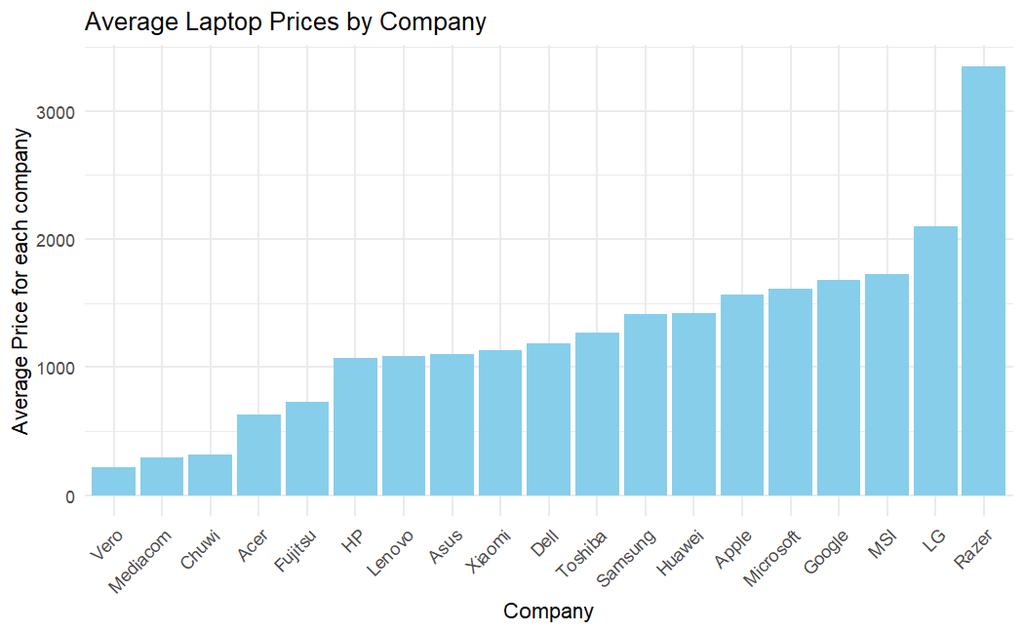

```r
#Company Bar chart
dataset %>%
  group_by(Company) %>%
  summarize(Average_Price = mean(Price_euros, na.rm = TRUE)) %>%
  ggplot(aes(x = reorder(Company, Average_Price), y = Average_Price)) +
  geom_bar(stat = "identity", fill = "skyblue") +
  labs(title = "Average Laptop Prices by Company", x = "Company", y = "Average Price for each company") +
  theme_minimal() +
  theme(axis.text.x = element_text(angle = 45,hjust=1))
```

#### Laptops types bar chart and Histogram

##### Top bought laptop type is Notebook and has Ideal price.

##### From the bar chart we see that Workststion laptops are Very Expensive, while Gaming and Ultrabook lapotps are Expensive but it is consider normal to have high prices due to the features it has.

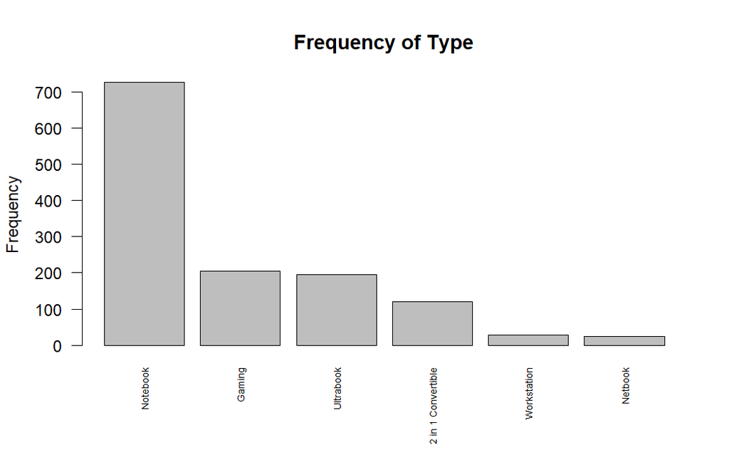

```r
#---
typeHist <- table(dataset$TypeName)
typeHist <- typeHist[order(-typeHist)]
barplot(typeHist, main = "Frequency of Type",
        ylab = "Frequency",
        las = 2,cex.names = 0.6)
```

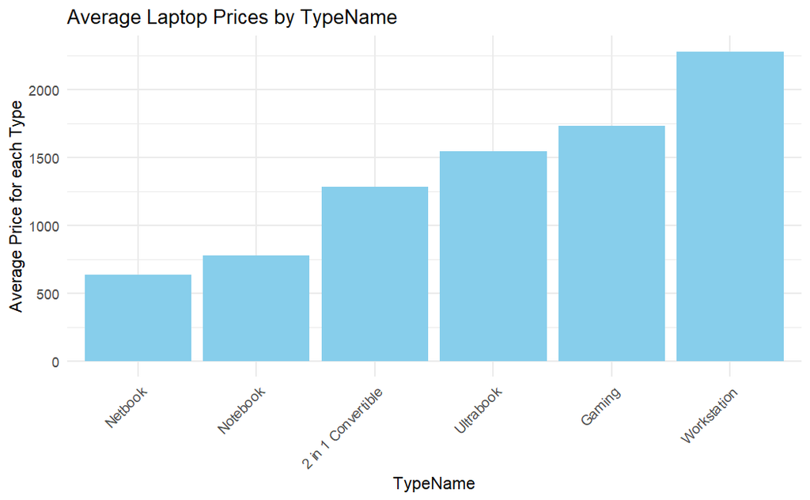

```r
# typeName
dataset %>%
  group_by(TypeName) %>%
  summarize(Average_Price = mean(Price_euros, na.rm = TRUE)) %>%
  ggplot(aes(x = reorder(TypeName, Average_Price), y = Average_Price)) +
  geom_bar(stat = "identity", fill = "skyblue") +
  labs(title = "Average Laptop Prices by TypeName", x = "TypeName", y = "Average Price for each Type") +
  theme_minimal() +
  theme(axis.text.x = element_text(angle = 45, hjust = 1))
```

#### Memory Sizes Histogram

##### Top 3 types of Memory Sizes are: 256GB, 1000GB, 500GB.

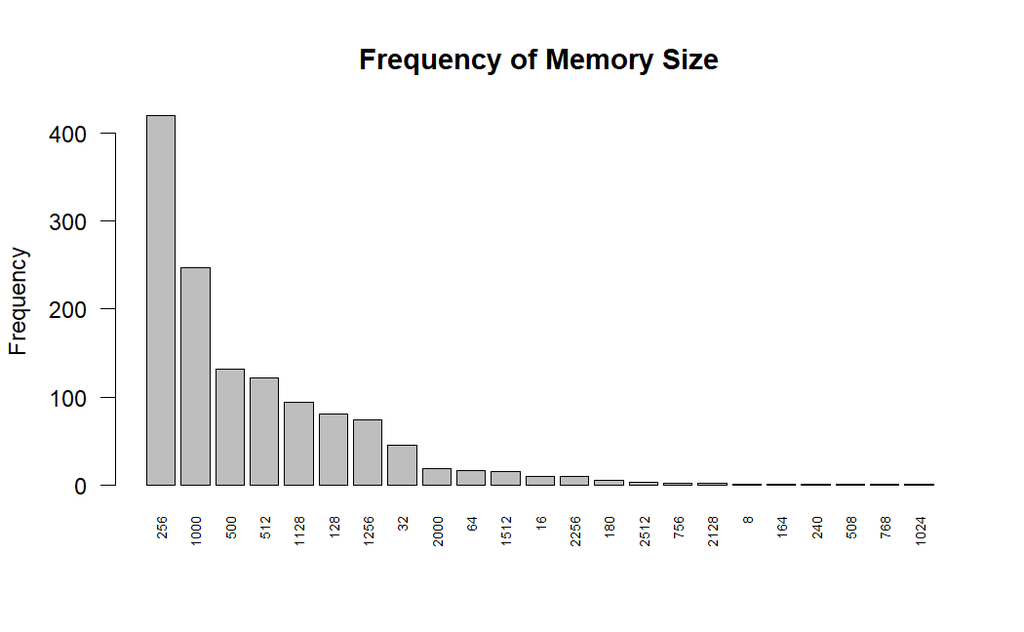

```r
#---
memorySizeHist <- table(dataset$MemorySize)
memorySizeHist <- memorySizeHist[order(-memorySizeHist)]
barplot(memorySizeHist,
        main = "Frequency of Memory Size",
        ylab = "Frequency",
        las = 2, cex.names=0.6)
```

#### Memory Type bar chart and Histogram

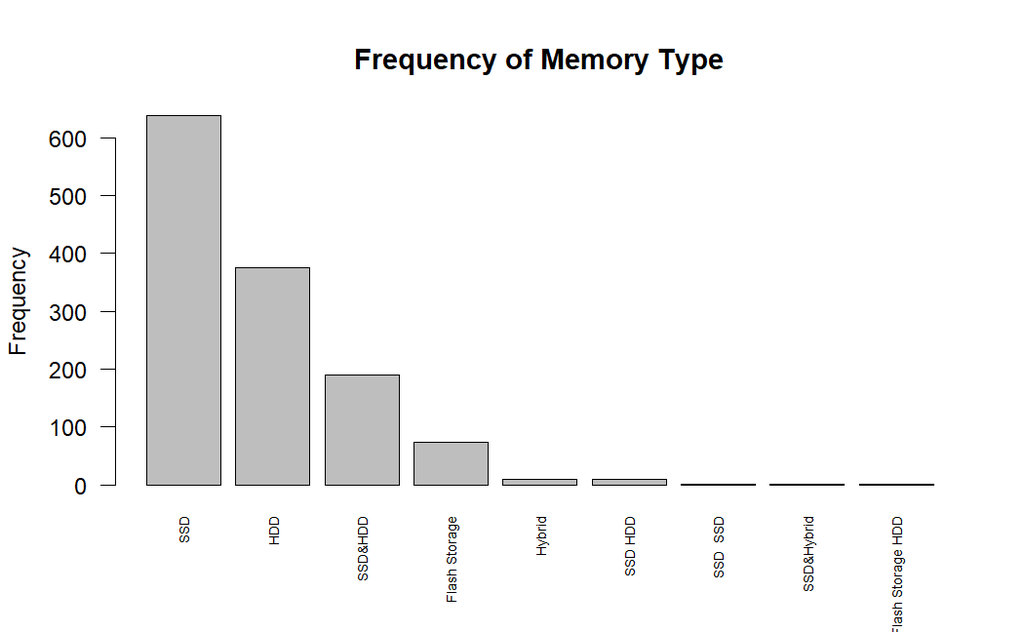

```r
#-------------------
memoryTypeHist <- table(dataset$MemoryType)
memoryTypeHist <- memoryTypeHist[order(-memoryTypeHist)]
barplot(memoryTypeHist, main = "Frequency of Memory Type",
        ylab = "Frequency",
        las = 2, cex.names = 0.6)
```

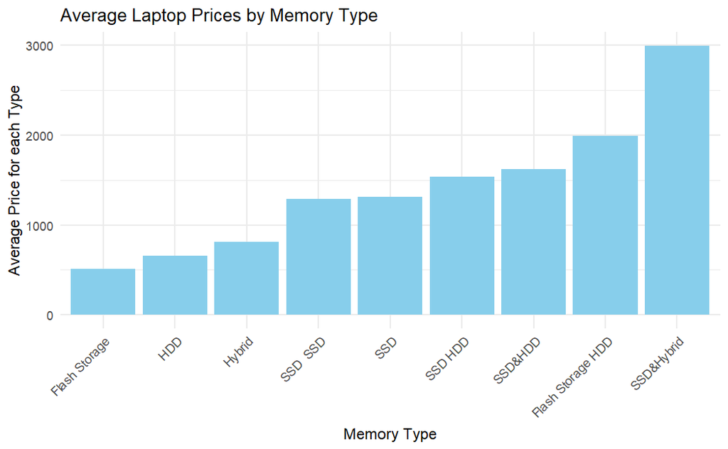

```r
#------------------

dataset %>%
  group_by(MemoryType) %>%
  summarize(Average_Price = mean(Price_euros, na.rm = TRUE)) %>%
  ggplot(aes(x = reorder(MemoryType, Average_Price), y = Average_Price)) +
  geom_bar(stat = "identity", fill = "skyblue") +
  labs(title = "Average Laptop Prices by Memory Type", x = "Memory Type", y = "Average Price for each Type") +
  theme_minimal() +
  theme(axis.text.x = element_text(angle = 45, hjust = 1))
```

### 7: Feature Selection

```r
# Feature selection
result=chisq.test(dataset$Price_euros , dataset$Company)
print(result)
```

```
    Pearson's Chi-squared test

data:  dataset$Price_euros and dataset$Company
X-squared = 13187, df = 14220, p-value = 1
```

```r
result=chisq.test(dataset$Price_euros , dataset$Product)
print(result)
```

```
    Pearson's Chi-squared test

data:  dataset$Price_euros and dataset$Product
X-squared = 476898, df = 487430, p-value = 1
```

```r
result=chisq.test(dataset$Price_euros , dataset$TypeName)
print(result)
```

```
    Pearson's Chi-squared test

data:  dataset$Price_euros and dataset$TypeName
X-squared = 4660.3, df = 3950, p-value = 1.951e-14
```

```r
result=chisq.test(dataset$Price_euros , dataset$ScreenResolution)
print(result)
```

```
    Pearson's Chi-squared test

data:  dataset$Price_euros and dataset$ScreenResolution
X-squared = 11163, df = 11060, p-value = 0.2438
```

```r
result=chisq.test(dataset$Price_euros , dataset$CPU)
print(result)
```

```
    Pearson's Chi-squared test

data:  dataset$Price_euros and dataset$CPU
X-squared = 7871.6, df = 7110, p-value = 3.259e-10
```

```r
result=chisq.test(dataset$Price_euros , dataset$MemoryType)
print(result)
```

```
    Pearson's Chi-squared test

data:  dataset$Price_euros and dataset$MemoryType
X-squared = 7773.8, df = 6320, p-value < 2.2e-16
```

```r
result=chisq.test(dataset$Price_euros , dataset$OpSys)
print(result)
```

```
    Pearson's Chi-squared test

data:  dataset$Price_euros and dataset$OpSys
X-squared = 7099.5, df = 6320, p-value = 1.254e-11
```

```r
result=chisq.test(dataset$Price_euros , dataset$GPU)
print(result)
```

```
    Pearson's Chi-squared test

data:  dataset$Price_euros and dataset$GPU
X-squared = 5195.8, df = 4740, p-value = 2.738e-06
```

##### we used the correlation for the numeric attributes and we have Ram,Weight,Inches,MemorySize.

##### Ram has a huge impact on the price since it provides smoother multitasking so laptops with larger ram have a higher price.

##### for the Weight and Inches it has an effect on the price but not as much as the Ram , since Weight and Inches have a less correlation with the class lable[price] than Ram and because they don’t offer a new or enhanced features but generally smaller and lighter are more portable and convenient which can make them more expensive, on the other hand heavier laptops may have more room for additional components and features such as a bigger Ram and more memory space which can also increase the price since the Ram and memorySize correlated positively.So, the Weight and Inches might play a role in determining the price of a laptop.these selected attributes will hepl us in building the classification model.

```r
result2=cor(dataset$Price_euros ,dataset$Inches)
print(result2)
```

```
[1] 0.06819667
```

```r
result2=cor(dataset$Price_euros ,dataset$Ram)
print(result2)
```

```
[1] 0.7430071
```

```r
result2=cor(dataset$Price_euros ,dataset$Weight)
print(result2)
```

```
[1] 0.2103698
```

```r
result2=cor(dataset$Price_euros ,dataset$MemorySize)
print(result2)
```

```
[1] 0.1589818
```

### 8: Labling the class label (Price_euros)

##### as shown in the bar plot the bar of [500-1000]had the most data in it, even about double the data in [1500-2000]bar, now there are two factors to keep in mind when distributing the class labels:

#### 1. the width and the frequency of data in the class -as it affects the balance of data-

#### 2. the logical distribution of prices, as -price range- is a previously known to human and -made by the human understanding- concept, the logic of the class distribution relies on being true to the concept of price ranges.

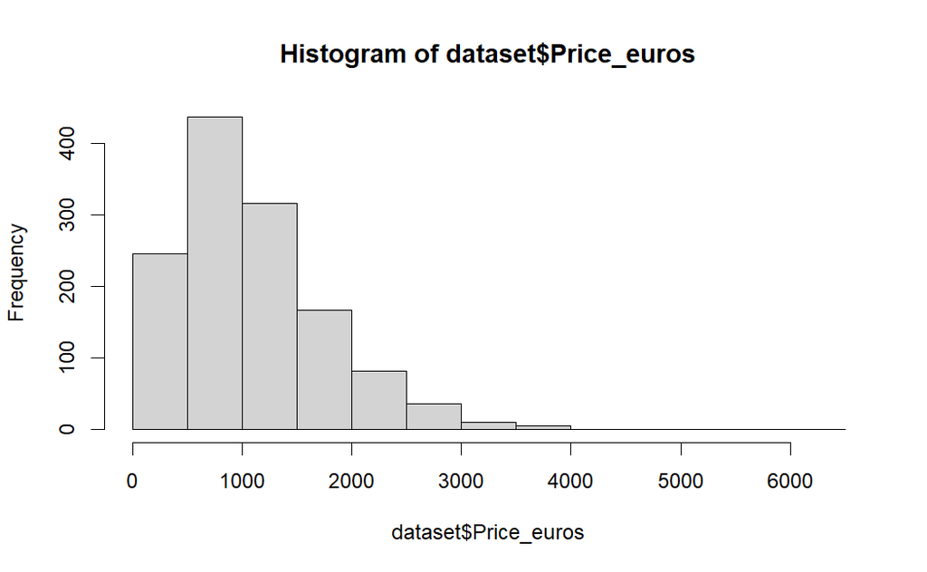

```r
## first draw a histogram to the study the distribution of data
hist(dataset$Price_euros)
```

##### first we take a look at the semi-standard of price labeling: inexpensive, moderately expensive, expensive, very expensive. we would add a fifth attribute “ideal price” as we believe that the bar [500-1000] brings the existence of good feature+good price.

##### now we devive the prices into 5 attributes of fixed width, [0-500] inexpensive, [500-1000]ideal price where most buyers are located, [1000-1500] moderately expensive, [1500-2000] expensive, [2000 and above] very expensive where least buyers are located.

```r
dataset$price=cut (dataset$Price_euros, breaks=c(0,500, 1000, 1500, 2000,7000), labels=c("inexpensive","ideal price","moderetly expensive","expinsive","very expensive"))
```

### dataset after simplification, encoding and labling

```r
head(dataset, 5)
```

|  | laptop_ID | Company | Product | TypeName | Inches | ScreenResolution | Ram | OpSys | Weight | Price_euros | CPU | GPU | MemoryType | MemorySize | price |
| --- | --- | --- | --- | --- | --- | --- | --- | --- | --- | --- | --- | --- | --- | --- | --- |
| 1 | 1 | Apple | MacBook Pro | Ultrabook | 13.3 | 4096000 | 8 | macOS | 1.37 | 1339.69 | Intel Core i5 | Intel Iris Graphics | SSD | 128 | moderetly expensive |
| 2 | 2 | Apple | Macbook Air | Ultrabook | 13.3 | 1296000 | 8 | macOS | 1.34 | 898.94 | Intel Core i5 | Intel HD Graphics | Flash Storage | 128 | ideal price |
| 3 | 3 | HP | 250 G6 | Notebook | 15.6 | 2073600 | 8 | No OS | 1.86 | 575.00 | Intel Core i5 | Intel HD Graphics | SSD | 256 | ideal price |
| 4 | 4 | Apple | MacBook Pro | Ultrabook | 15.4 | 5184000 | 16 | macOS | 1.83 | 2537.45 | Intel Core i7 | AMD Radeon Graphics | SSD | 512 | very expensive |
| 5 | 5 | Apple | MacBook Pro | Ultrabook | 13.3 | 4096000 | 8 | macOS | 1.37 | 1803.60 | Intel Core i5 | Intel Iris Graphics | SSD | 256 | expinsive |

### checking the balance of the dataset class label

##### looking at the bar plot, about 20% of data is inexpensive and about 35% of it is an ideal price,

##### which means about half of the data lies under moderately expensive and above,

##### and looking at {ideal price} and {very expensive} there is a big difference observed in the amount of data available. If we are making a model based on both the dataset accuracy predicting ideal price will be higher compared to very expensive.

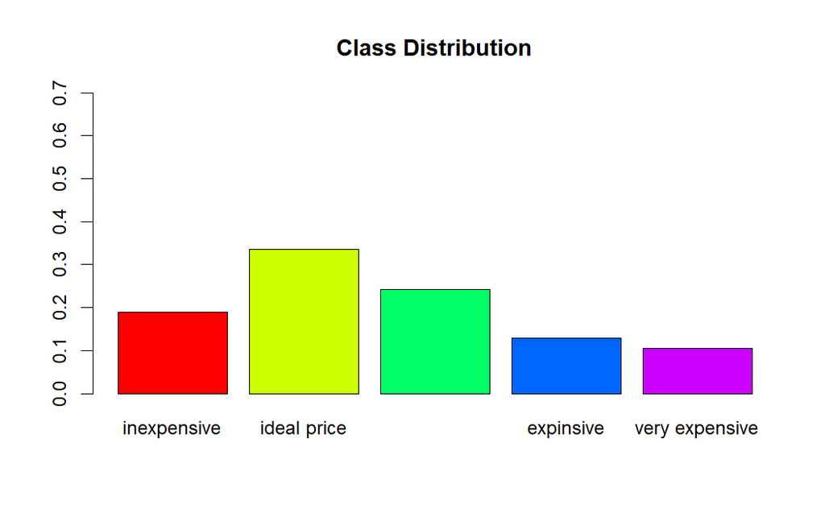

```r
barplot(prop.table(table(dataset$price)),
        col = rainbow(5),
        ylim = c(0, 0.7),
        main = "Class Distribution")
```

### 9: deleting multivalue attribures

##### removing the product and ID attributes , since Product has 600 and ID has 1303 unique values , both are a multivalued attribute so it has to be removed from the dataset because the information gain and gini index are biased towards unique and multivalued attributes and this will mislead the classification.

```r
#delete laptop_ID attribute
dataset <- dataset[, -which(names(dataset) == "laptop_ID")]
dataset <- dataset[, -which(names(dataset) == "Product")]
```

##### saving all the changes in the original dataset to a new dataset “new_dataset” to make it easier to handle the classification and clustering steps.

```r
write.csv(dataset , file="new_dataset.csv" ,row.names = FALSE)
```

#### to handle imbalanced data when predicting : the classification and clustering methods will be implemented.